# Visualizing Asymmetry

2026-10-23

## Introduction

Asymmetric matrices are square matrices with an equal number of rows and columns, each referring to the same set of objects. In such matrices, at least some elements in the upper triangle differ from their corresponding elements in the lower triangle. Formally, for an asymmetric matrix $Q$, we have $Q \neq Q^T$, where $Q^T$ represents the transpose of matrix $Q$.

A practical example of an asymmetric matrix is a migration table, where both rows and columns represent the same countries. In this context, rows indicate home countries, while columns represent destination countries. These tables can be analysed to address two key questions: Which countries are similar? For instance, countries that exchange more students often share cultural or other similarities. Which countries are more successful in attracting students? This highlights the appeal of specific countries as study destinations.

The following script generates data from the Erasmus student exchange program for analysis. To maintain clarity in the results, this example we use a portion of the data with five countries.

```r
library("asymmetry")
data("studentmigration")
idx <- c(3,4,25,27,31) #select five countries
studentmigration[idx,idx]
```

```
##     CZ  DK  FI  UK  TR
## CZ   0 190 420 582 230
## DK  42   0  28 650 119
## FI 181 106   0 643  48
## UK 186 244 228   0  95
## TR 615 232 143 617   0
```

The data give the number of inbound and outbound students in the Erasmus program. These migration data of students participating in the Erasmus program may give insight in the similarity between countries and the attractiveness of countries. The Erasmus program is a student exchange program from the European Union. Three million students had taken part since the start of the program in 1987. To join this program a student has study at least three months or do an internship of at least two months in another country. The entries in the table are as follows: 190 students move from the Czech Republic (CZ) to Denmark (DK), whereas 42 students move from Denmark to the Czech Republic. The complete table lists the home and destination country of 268.142 students in the academic year 2012- 2013.

## Decomposition of an asymmetric matrix

The decomposition of an asymmetric matrix into a symmetric matrix and a skew-symmetric matrix is an elementary result from mathematics that is the cornerstone of this package. The decomposition into a skew-symmetric and a symmetric component is written as:
$$Q
= S + A,$$
where $S$ is a symmetric matrix with averages $(q_{ij}+q_{ji})/2$, and $A$ is a skew-symmetric matrix with elements $(q_{ij}-q_{ji})/2$. A square matrix is skew-symmetric if the transpose can be obtained by multiplying the elements of the matrix by minus one, that is $A^T = -A$. Another, perhaps more convenient way to state this property is $a_{ij}=-a_{ji}$, that is, if we interchange the subscripts the sign changes. It follows that the diagonal elements $a_{ii}$ of a skew-symmetric matrix are zero.

The skew symmetric part $A$ of a portion of the data is generated by the following script

```r
q1 <- skewsymmetry(studentmigration[idx,idx])
q1$A
```

```
##        CZ     DK     FI    UK     TR
## CZ    0.0   74.0  119.5 198.0 -192.5
## DK  -74.0    0.0  -39.0 203.0  -56.5
## FI -119.5   39.0    0.0 207.5  -47.5
## UK -198.0 -203.0 -207.5   0.0 -261.0
## TR  192.5   56.5   47.5 261.0    0.0
```

Similarly, the symmetric part is obtained by

```r
q1$S
```

```
##       CZ    DK    FI    UK    TR
## CZ   0.0 116.0 300.5 384.0 422.5
## DK 116.0   0.0  67.0 447.0 175.5
## FI 300.5  67.0   0.0 435.5  95.5
## UK 384.0 447.0 435.5   0.0 356.0
## TR 422.5 175.5  95.5 356.0   0.0
```

The decomposition is additive, and because the two components $S$ and $A$ are orthogonal, the decomposition of the sum of squares of the two matrices is also additive. Because the sum of the cross products vanishes, the sum of squares consists of two components

$$\sum_{i=1}^n\sum_{j=1}^n q_{ij}^2 =
\sum_{i=1}^n\sum_{j=1}^n s_{ij}^2 +
\sum_{i=1}^n\sum_{j=1}^n a_{ij}^2.$$

The summary method provides the sum of squares due to symmetry and the sum of squares due to skew-symmetry.

```r
summary(q1)
```

```
##                     SSQ   Percent
## Symmetry      1980666.5  79.49979
## Skew-symmetry  510744.5  20.50021
## Total         2491411.0 100.00000
```

The additivity of the two sums of squares provides a justification for analyzing the two components independently. For instance, the symmetric part can be represented by a symmetric method such as multidimensional scaling or hierarchical cluster analysis. Suggestions for the analysis of the skew-symmetric part are the heatmap, the linear model or the Gower diagram. In a later stage the results of these analyses of the two components can possibly be used to suggest a joint model the table $Q$. The results of a hierarchical cluster analysis are shown below.

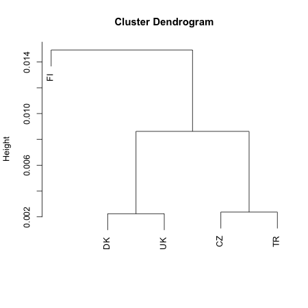

```r
clus <- hclust(as.dist(1/q1$S))
plot(clus,xlab=NA,sub=NA)
```

The linear model provides a useful summary of the skew-symmetric matrix. This model is based on the difference of the scale values $c_i$ of two objects, and is written as

$$a_{ij}=c_i - c_j.$$

It is easily seen that this model is skew-symmetric because we have $a_{ji} = c_j - c_i = -(c_i - c_j) = -a_{ij}.$ Let
$$c_j = {1 \over n}
\sum_{i=1}^n a_{ij}$$
denote the average of a column of this matrix. This estimate minimizes the sum of squares loss function, and is therefore a least-squares estimate. There is an indeterminacy in the model, because $\tilde{c_i} = c_i + d$, where $d$ is any number is also a solution with the same least-squares loss. Therefore, the identification constraint $\sum_{i=1}^n c_i = 0$ is used. An example is given by the following line of code.

```r
   q1$linear
```

```
##     CZ     DK     FI     UK     TR
##   39.8    6.7   15.9 -173.9  111.5
```

Inserting the definition of skew-symmetry in this estimate, that is
$$c_j = {1 \over n} \sum_{i=1}^n a_{ij} =
{1 \over (2n)} \sum_{i=1}^n ( q_{ij} - q_{ji} )$$
we see that this estimate is equal to ${1 \over 2}$ the difference of the column mean and the row mean

## Heatmap

Color is widely used in data visualization to show data values. A heatmap displays values in a data matrix by colors and reorders the rows and columns of this matrix by dendograms. The heatmap function **hmap** is a quick way to visualize skew-symmetric data. The order of the rows and columns is given by the row sums of the matrix, and not by a dendogram as in a usual heatmap. A permutation of the rows and columns is derived from the number of positive elements in a row of the matrix. If the matrix has no circular triads all values in the upper triangle are positive and all values in the lower triangle are negative. This method can display the signs or values of the elements in the matrix. The option dominance gives the signs of the skew-symmetric matrix, otherwise the values are shown.

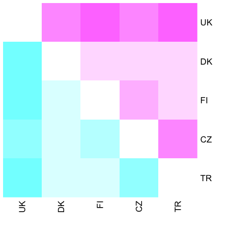

```r
hmap(q1, dominance = FALSE, col = cm.colors(n = 9))
```

Blue values correspond to positive values, whereas red values correspond to negative values. The intensity of the colors show the magnitude. Because the values in the column UK are blue, which point to positive net migration, the UK attracts more students from abroad than any other country. In this example, the UK is the most popular destination for international students. The second most popular country is Denmark (DK), followed by Finland and the Czech republic (CZ). The least popular country of these five countries is Turkey. By permuting the rows and columns the data in this order the values in the upper triangle are red, and the values in the lower triangle are blue, corresponding to negative and positive values respectively in the data matrix.

## Slide-vector model

The slide vector model is a multidimensional scaling (MDS) model for asymmetric data. MDS fits symmetric distances to data, whereas this model fits modified distances which are asymmetric. A distance model is fitted to the symmetric part of the data whereas the asymmetric part of the data is represented by projections of the coordinates onto the slide-vector. The slide-vector points in the direction of large asymmetries in the data. The distance is modified in such a way that the distance between two points that are parallel to the slide-vector is larger in the direction of this vector. The distance is smaller in the opposite direction. If the line connecting two points is perpendicular to the slide-vector the difference between the two projections is zero. In this case the distance between the two points is symmetric. The algorithm for fitting this model is derived from the majorization approach to multidimensional scaling.

The slide-vector model is given by the following equation
$$d_{ij}(X;z)=\sqrt{\sum_{s=1}^p(x_{is}-x_{js}+z_{is})^2}.$$

The squared distances can be decomposed in a linear skew-symmetric and symmetric part.
$$d_{ij}^2(X;z)=\sum_{s=1}^p (x_{is}-x_{js})^2+\sum_{s=1}^p z_{is}^2 +
2\sum_{s=1}^p( x_{is}-x_{js})z_{is}.$$
The following lines of code generate a two-dimensional representation of the English towns data for the slide-vector model.

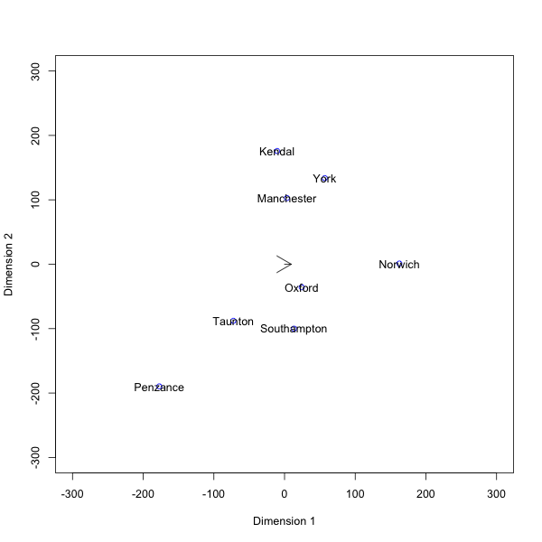

```r
data(Englishtowns)
v<-slidevector(Englishtowns, ndim = 2, itmax = 2500, eps = .0000001, verbose = FALSE)
plot(v, col = "blue", ylim = c(-300, 300), xlim = c(-300, 300))
```

A decomposition of the residuals can be obtained using the following lines of code

```r
q2 <- skewsymmetry(v$resmat)
summary(q2)
```

```
##                    SSQ   Percent
## Symmetry      1650.078  56.18866
## Skew-symmetry 1286.596  43.81134
## Total         2936.674 100.00000
```

## MDS with unique dimensions

This MDS model has both common that are shared by all objects and unique dimensions that apply to one object and not to the other objects. The shared dimensions provide a Euclidean map of the objects in low-dimension space, whereas unique dimension apply to one object. A unique dimension has a non zero value for only one object, the coordinates for the other objects are zero. There are as many unique dimensions as there are objects. An asymmetric version of this model has two sets of unique dimensions: one for the rows and one for the columns. The distance in this model is defined as:
$$d_{ij}(X)=\sqrt{\sum_{s=1}^p (x_{is}-x_{js})^2 +
r_{i}^{2}+c_{j}^{2}}.$$

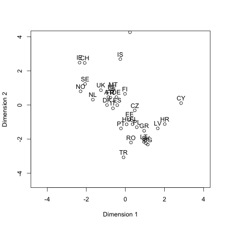

```r
data("studentmigration")
mm<-studentmigration
mm[mm==0]<-.5          # replace zeroes by a small number
mm <- -log(mm/sum(mm)) # convert similarities to dissimilarities
v<-mdsunique(mm, ndim = 2, itmax = 2100, verbose=FALSE, eps = .0000000001)
plot(v, yplus = .3, ylim = c(-4.5, 4), xlim = c(-4.5, 4))
```

## ASYMSCAL

The ASYMSCAL model is a weighted Euclidean model proposed by Young. The model is a distance model with weights for each row of the datatable. These weights stretch or shrink the dimensions of the model, and if they are varying asymmetry is predicted by the model. If the weights are all equal, the distances are symmetric resulting in the standard Euclidean distance model.